# Introduction to data

Some define statistics as the field that focuses on turning information into knowledge. The first step in that process is to summarize and describe the raw information – the data. In this lab we explore flights, specifically a random sample of domestic flights that departed from the three major New York City airports in 2013. We will generate simple graphical and numerical summaries of data on these flights and explore delay times. Since this is a large dataset, along the way you’ll also learn the indispensable skills of data processing and subsetting.

## Getting started

### The data

The [Bureau of Transportation Statistics](http://www.rita.dot.gov/bts/about/) (BTS) is a statistical agency that is a part of the Research and Innovative Technology Administration (RITA). As its name implies, BTS collects and makes transportation data available, such as the flights data we will be working with in this lab.

As usual, you can import this data from Rguroo’s `OpenIntro` **Dataset Repository**. The dataset we want to import is `nycflights`. Locate the dataset in the repository and click on the information icon to the right of the dataset name to read some information about the dataset. In particular, you can see the **codebook** (description of the variables) on that page. One of the variables refers to the carrier (i.e. airline) of the flight, which is coded according to the following system.

- `carrier`: Two letter carrier abbreviation.
  - `9E`: Endeavor Air Inc.
  - `AA`: American Airlines Inc.
  - `AS`: Alaska Airlines Inc.
  - `B6`: JetBlue Airways
  - `DL`: Delta Air Lines Inc.
  - `EV`: ExpressJet Airlines Inc.
  - `F9`: Frontier Airlines Inc.
  - `FL`: AirTran Airways Corporation
  - `HA`: Hawaiian Airlines Inc.
  - `MQ`: Envoy Air
  - `OO`: SkyWest Airlines Inc.
  - `UA`: United Air Lines Inc.
  - `US`: US Airways Inc.
  - `VX`: Virgin America
  - `WN`: Southwest Airlines Co.
  - `YV`: Mesa Airlines Inc.

When you are done reading the information about the data, import the dataset to your **Data** toolbox.

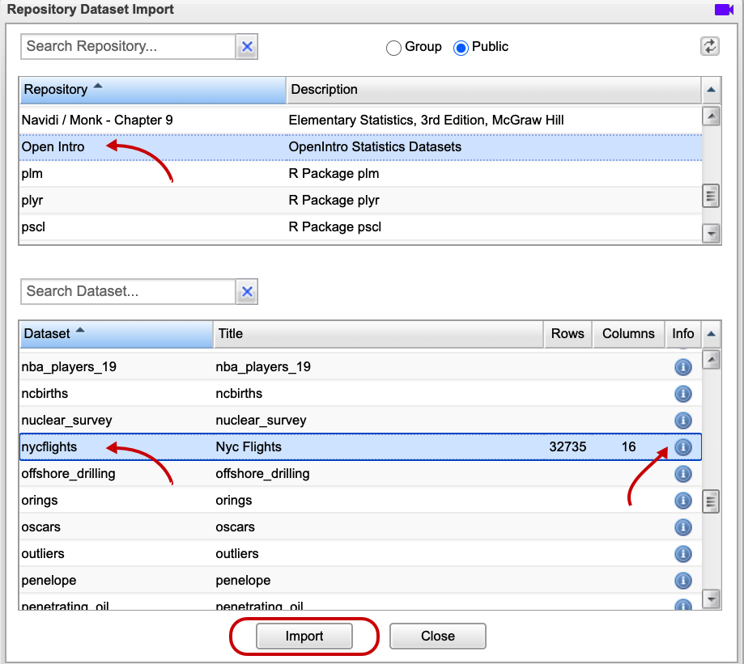

*Rguroo Dataset Repository - Open Intro to import nycflights*

**Tip:** Sometimes, when you get lists, like the ones shown in the figure above, the columns’ elements are not alphabetically ordered. To order them alphabetically, click on the column header. In the screenshot above, we have clicked on the headings `Repository` and `Dataset` in the first column of the top and bottom panels to make the column elements alphabetically ordered.

The dataset *nycflights* that shows up in your workspace is a *data matrix*, with each row representing an *observation* and each column representing a *variable*. Rguroo calls this data format a **Rguroo dataset** or **data frame**, which is a term that will be used throughout the labs. For this dataset, each *observation* (or each row) is a single flight.

To view the names of the variables and some summary information, right-click the *nycflights* dataset and select **Dataset Summary**. You can also double-click the dataset name to view the first 100 rows and 15 columns of the data frame.

The *nycflights* data frame is a massive trove of information. Let’s think about some questions we might want to answer with these data:

- How delayed were flights that were headed to Los Angeles?
- How do departure delays vary by month?
- Which of the three major NYC airports has the best on time percentage for departing flights?

## Analysis

### Departure delays

Let’s start by examining the distribution of departure delays of all flights with a histogram. Since this is a plot, we need to open the **Plots** toolbox, click **Create Plot**, and select **Histogram**.

We start by selecting the *nycflights* `Dataset` and the `Variable` *dep_delay* to plot.

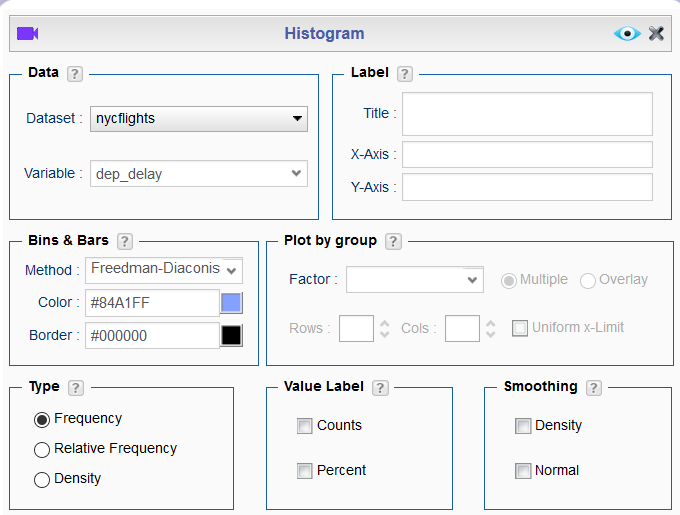

*Histogram Basics dialog box*

Histograms are generally a very good way to see the shape of a single distribution of numerical data, but that shape can change depending on how the data is split between the different bins. Each software has a default method for determining the bin locations and widths. Rguroo’s default method is the “Freedman-Diaconis” method, named after two famous statisticians, David Freedman and Persi Diaconis (see the `Method` dropdown in the `Bins & Bars` section of the Histogram dialog box, shown in the figure above). click the `Preview` button to see the default histogram.

**A note about the border color:** The default border color for bins in Rguroo is light gray. In this example, the bins are so small that with the default border color the bars blend into the background! So, we have changed the border color to black in the screenshot above. You should do the same for this example.

In Rguroo you can easily define the bin width you want to use. To define your own bins, click and open the `Bins, Bars, Smoothing` section. In the `Bins & Bars` tab go to the `Bin Breakpoints` section. In this section there are different methods for setting the bin locations and bin widths. Let’s select the `Center` and `Width` option. As shown in the figure below, type *100* in the `Center` box and type *15* in the `Width` box. click the `Preview` button to see the histogram.

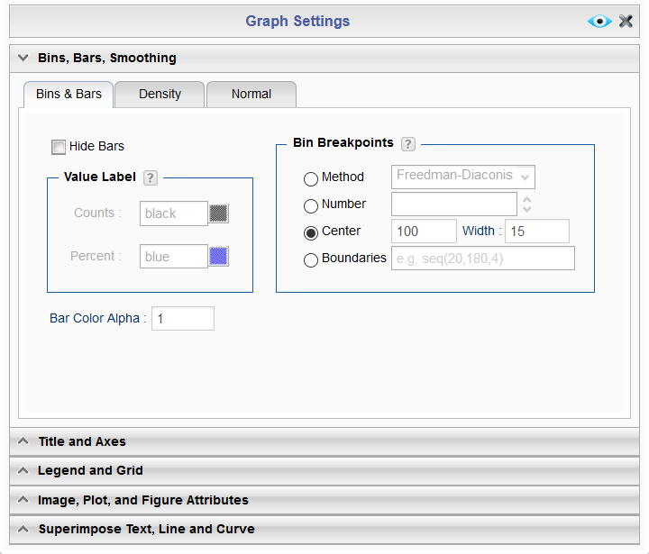

*Selecting Bin Center 100 and Bin Width 15*

Once you have seen the histogram, go back to the `Bin Breakpoints` section in the dialog box and change to a bin width of 150, as shown below.

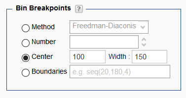

*Selecting Bin Center 100 and Bin Width 150*

1. Look carefully at these three histograms. How do they compare? Are features revealed in one that are obscured in another?

**Tip:** To view all three histograms at the same time, either copy and paste each graph to your report separately, or make each one in a separate tab by selecting the **Histogram** dialog box three times, with each dialog box consisting of one of the three options.

If you want to visualize only delays of flights headed to Los Angeles, you need to first filter the data for flights with the destination (LAX). There are two options: One is to filter the data within the **Histogram** function. Another option is to use the **Subset** function in the **Data** toolbox to obtain the subset of the data consisting of only flights with LAX destination, and then use this dataset to plot your histogram. We explain both methods below.

#### Subsetting in the Histogram function directly

To filter the data with the destination to LAX, we use the R code `dest == "LAX"`. Specifically, in the `Variable` box in the dialog box of **Histogram**, we write `dep_delay[dest == "LAX"]`, as shown in the figure below. `LAX` is in quotation marks since it is a character string.

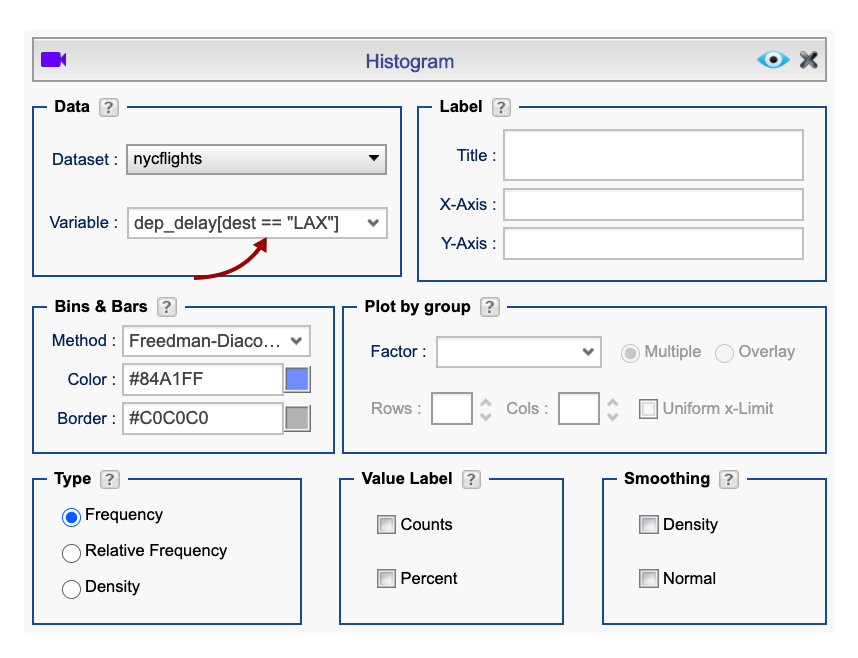

*Dialog box for histogram of departure dalays at LAX*

Let’s understand this command. Square brackets that follow a variable name are used to extract a subset of elements of the variable. For example, if you write `dep_delay[3:10]`, the result is a new variable that consists of the third through the tenth component of the variable `dep_delay`. In our example, the command `dest == "LAX"` is a new variable with logical values of `TRUE` corresponding to every destination that is LAX and `FALSE` corresponding to destinations that are not LAX. So, the final result of `dep_delay[dest == "LAX"]` in Rguroo is that only elements with destination LAX will be included from the variable `dep_delay`. That is, the values corresponding to the `FALSE` elements of `dest == "LAX"` will be dropped.

#### Subsetting (filtering) the data

As noted earlier, another way to get a histogram of departure delays for LAX is to get a subset of the data that only includes data values with destination LAX, and then use that dataset in the **Histogram** function to plot the variable *dep_delay*. Below, we show two approaches for obtaining a subset of the data: one utilizes the filtering functionality in Rguroo’s dataset editor, while the other employs Rguroo’s **Subset** function. Note that subsetting a dataset (typically, to select specific observations) is also referred to as filtering. For straightforward subsets like the one in this lab, using the dataset editor is more convenient. However, Rguroo’s subset editor provides the capability to subset data based multiple criteria.

##### Filtering using Rguroo’s dataset editor

To obtain a dataset containing only data values with the destination LAX using Rguroo’s dataset editor, follow these steps:

- Open the dataset editor by going to the **Data** toolbox and double-clicking on the name of the dataset, *nycflights*. Alternatively, you can right-click on the dataset name and select the `Edit` option.
- In the dataset editor, locate the filter tab , which is vertically displayed on the right-hand side of the editor. You will see a list of the names of the variables.
- Expand the *dest* dropdown menu to display the list of available destinations and uncheck the `(Select All)` checkbox to remove all current selections.
- Check the checkbox next to LAX. You can also type “LAX” in the search box to quickly find and select it.
- Save the newly created subset of data as *lax_flights*, by typing the name in the the *Save As* textbox.

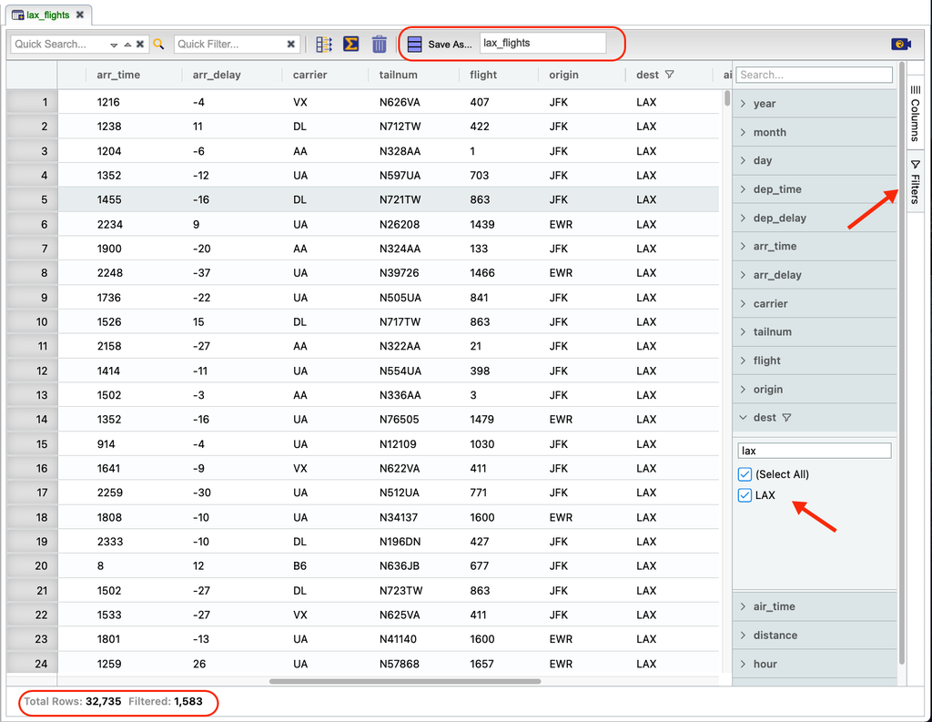

*Filtering data using Rguroo’s dataset editor*

#### Subsetting (filtering) the data by using the Subset function

If you have already used the dataset editor to subset your data and do not wish to learn about Rguroo’s Subset function, you can skip this subsection and proceed to the next section, “Making a histogram.”

To subset the data using Rguroo’s subset function, go to the **Data** toolbox, select **Functions**, and then click on **Subset**. A dialog box titled **Data Subset** should appear.

As usual, we first need to select the *nycflights* `Dataset`. Next, we want to filter to get specific observations in the dataset (rows), so we look at the `Row Selection` section. There are two buttons in this box. The `Sequence` button is used when we know the specific row numbers we want to include. The `Logical Expression` button is used when we know the condition(s) that the rows that we want to include from the dataset should satisfy. In our case here, we want the `Logical Expression` option. Specifically, we want to subset based on the logical expression `dest == "LAX"`.

In the `Logical Expression Creator` dialog, click the green plus sign at the bottom right to add a logical expression. The figure below shows the logical expression that we need to specify.

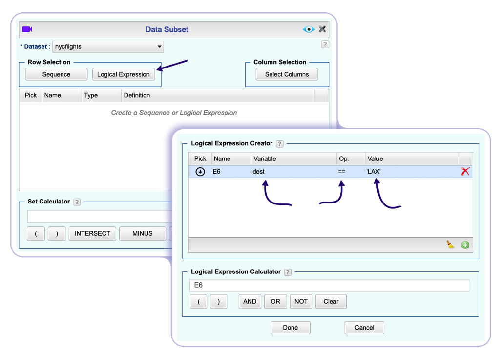

*Dialog box for subsetting data using logical expressions*

Let’s take a second to decipher the logical expression we’ve created.

- `dest` is the name of the variable we want to filter on. You can select this directly from the left dropdown menu.
- `==` means “if it’s equal to”. You can select this directly from the middle dropdown menu.
- `LAX` is the value we want `dest` to be equal to. You can usually select this directly from the right dropdown menu, but there are so many flight destinations that Rguroo won’t list them. Instead, we can directly type the value in. We write it inside single quotation marks since it is a character string and not a number.

**Logical operators:** Filtering for certain observations (e.g. flights from a particular airport) is often of interest in data frames where we might want to examine observations with certain characteristics separately from the rest of the data. To do so, you can use the **Data Subset** dialog with the `Logical Expression Creator` and a series of **logical operators**. The most commonly used logical operators for data analysis are as follows:

- `==` means “equal to”
- `!=` means “not equal to”
- `>` or `<` means “greater than” or “less than”
- `>=` or `<=` means “greater than or equal to” or “less than or equal to”

**Save** your new data subset as *lax_flights*.

#### Graphical and numerical summaries of a subset

Once you have saved a subset in Rguroo, you can use it as an Rguroo dataset. For example, you can make a histogram of the departure delays of only LAX flights, using the *lax_flights* dataset that you created.

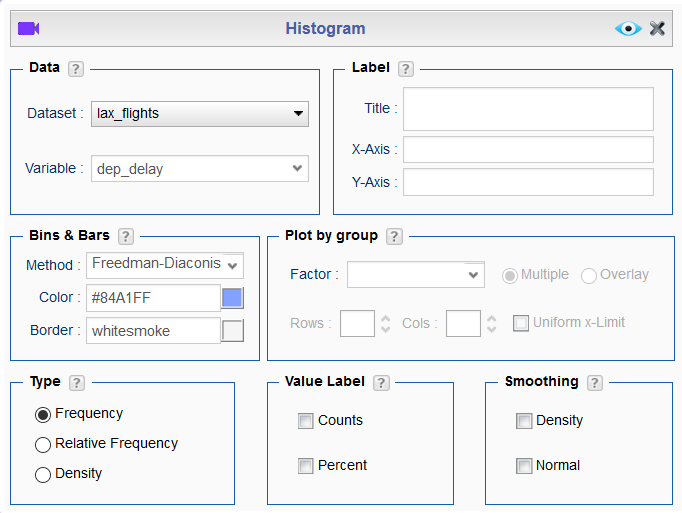

*Histogram dialog box to plot the departure delays for flights to LAX*

You can also obtain a custom numerical summary of the departure delays for these flights by going to the **Data** toolbox, clicking **Function** and then selecting **Summary Statistic**:

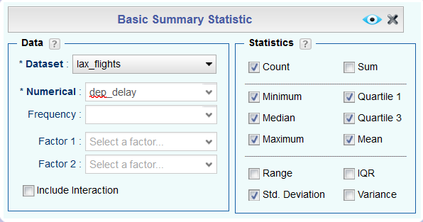

*Summary Statistic dialog box*

**Summary statistics:** Some useful summary statistics for a single numerical variable are as follows:

- `Mean`
- `Median`
- `Standard Deviation`
- `Variance`
- `IQR` (interquartile range)
- `Minimum`
- `Maximum`

See if you can find each of those summary statistics in the Rguroo dialog. Check the boxes for those statistics, then View the output. Note that you will have to click the **+** sign next to “All Observations” to view the values.

#### Filtering based on multiple criteria

You can also filter based on multiple criteria. Suppose you are interested in flights headed to San Francisco (SFO) in February. Again, you can use the dataset editor to filter the data or Rguroo’s subset function. We show both methods in the subsections below.

##### Multiple criteria filtering using the dataset editor

To filter the *nycflights* dataset and obtain a subset that includes only data values with the destination San Francisco (SFO) in February you can use the dataset editor and follow these steps:”

- Open the dataset editor by going to the **Data** toolbox and double-clicking on the name of the dataset, *nycflights*. Alternatively, you can right-click on the dataset name and select the `Edit` option.
- In the dataset editor, locate the filter tab , which is vertically displayed on the right-hand side of the editor. You will see a list of the names of the variables.
- Expand the *dest* dropdown menu to display the list of destinations and uncheck the `(Select All)` checkbox to remove all current selections.
- Check the checkbox next to SFO. You can also type “SFO” in the search box to quickly find and select it.
- Similarly, expand the *month* dropdown menu to display the list of months, uncheck the `(Select All)` checkbox to remove all current selections, then check the checkbox next to *2*.
- Save the newly created subset of data as *sfo_feb_flights*, by typing the name in the the *Save As* textbox.

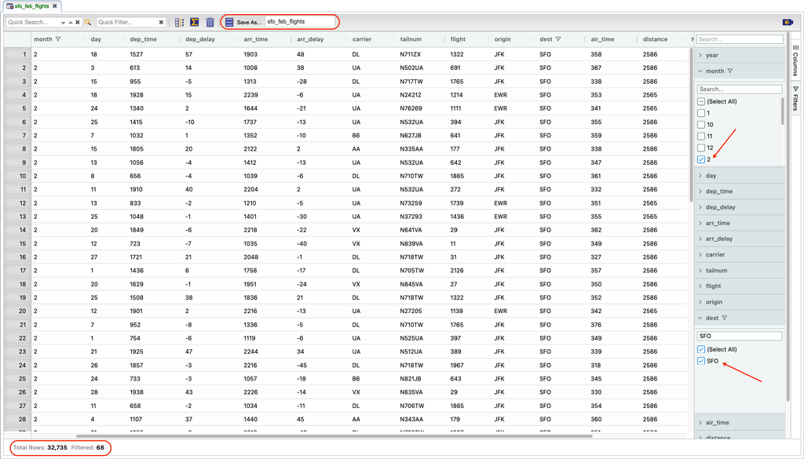

*Multiple criteria filtering*

##### Multiple criteria filtering using the Subset function

If you have already used the dataset editor to subset your data and do not wish to learn about Rguroo’s subset function, youcan skip this subsection and proceed to the next subsection.

To use Rguroo’s **Subset** function to filter the *nycflights* dataset and obtain a subset that includes only data values with the destination San Francisco (SFO) in February, you need to find flights that are headed to SFO **AND** are in February. This consists of a combination of two logical expressions. To set this up, in the **Data** toolbox, click **Functions**, select **Subset**, select the *nycflights* dataset, then click `Logical Expression`, just like we did earlier. First, we’ll put in a logical expression for flights headed to SFO, and then we’ll put in another logical expression for the flights in February (month 2). Note that we’ll have to type in both *‘SFO’* and the number *2* in the `Value` column, as shown in the figure below.

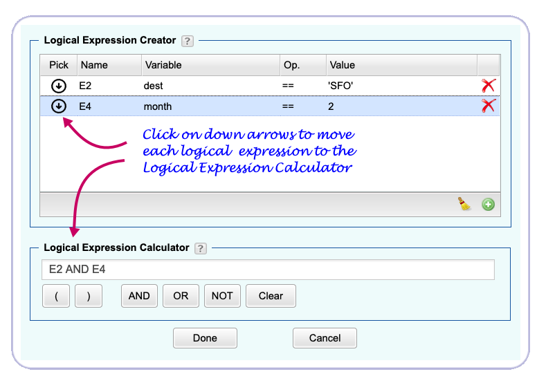

*Combining logical expressions*

Once you have each of the logical expressions in place, you need to combine them with an **AND**. To combine logical expressions, we use the `Logical Expression Calculator` at the bottom of the dialog box. Click the down arrow in the `Pick` column for the logical expression corresponding to the SFO flights to move it to the `Logical Expression Calculator`. Then, click the `AND` button, and finally move the logical expression for February down to the `Logical Expression Calculator`. When you’re done, click `Done` and click the `Preview` button to view the output. **Save** the new output as *sfo_feb_flights*.

**About the Logical Expression Calculator:** The `Logical Expression Calculator` can be used to combine logical expressions using *logical operations* `AND`, `OR`, or `NOT`. For example, if you are interested in either flights headed to SFO or in February, you would combine the two expressions using the `OR` button.

1. How many flights are headed to SFO in February? **Hint:** The answer is less than 100, so you can simply look at the number of rows in the **Data Viewer**.
2. Describe the distribution of the **arrival** delays of these flights using a histogram and appropriate summary statistics. **Hint:** The summary statistics you use should depend on the shape of the distribution.

Another useful technique is quickly calculating summary statistics for various groups in your data frame. For example, we can use the **Summary Statistic** dialog on the *sfo_feb_flights* dataset but tell Rguroo to group the departure delays by the origin airport by selecting the variable *origin* in the `Factor 1` dropdown menu, as shown below.

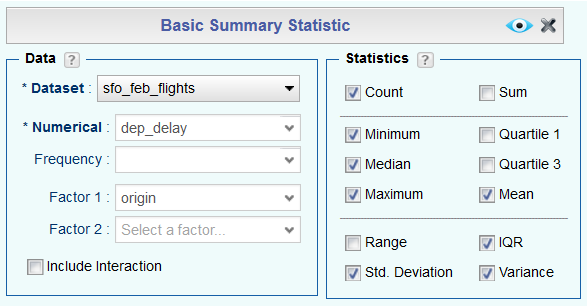

*Summary Statistic dialog to get summary by flight origin*

To view the summary statistics of departure delays based on the origin airport, click the **+** sign to the left of *origin* in the output:

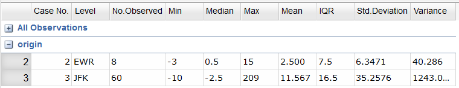

*Rguroo output of Summary Statistic*

1. Use the **Summary Statistic** dialog to calculate the median and interquartile range for *arr_delay*s of flights in the *sfo_feb_flights* data frame, grouped by *carrier*. Which carrier has the most variable arrival delays?

### Departure delays by month

Which month would you expect to have the highest average delay departing from an NYC airport?

Let’s think about how you could answer this question. We need to do three things:

- `group` by months
- `summarize` the average departure delays for each month
- `sort` the months based on their average departure delays

We now know how to do the first two of these things, but there’s a bit of a problem. When we open the **Summary Statistic** dialog, we can’t select *month* as `Factor 1`. The reason for this is that Rguroo has classified month as a *numerical* variable, not a *categorical* variable. To overwrite this classification, we need to right-click the *nycflights* dataset and select **Open** to open the *nycflights* in the Dataset Editor (alternatively, you can double click on the name of the dataset.). Click the `Variable Properties icon` and in the dialog that pops up, select `Variable Properties`. Select the *month* variable and change its `Type` to `Nominal`, as shown below.

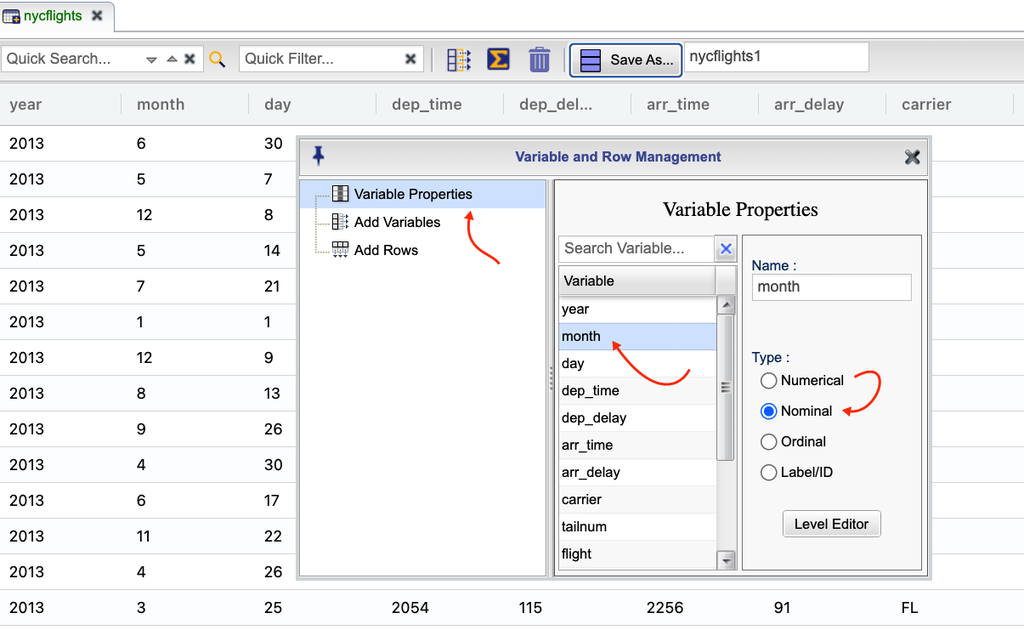

*Data Editor to modify variable types*

Because you have made changes to the dataset after creating and saving output based on the dataset, you cannot overwrite the original dataset. Use the *Save As* textbox at the top of the tab to save the new dataset as *nycflights1*. Now open a new **Summary Statistic** dialog, select the dataset *nycflights1*, and *month* will now appear as a `Factor 1` option, as shown in the dialog below.

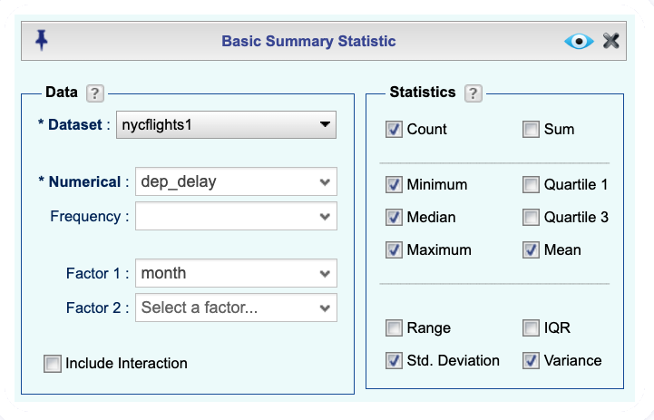

*Summary Statistic dialog to get summary by month*

Use the **Save As** text box at the top of the output tab to save the summary as *nycflights_month*. We’ll use this dataset to perform the last step of sorting the dataset. In the **Data** toolbox, click **Functions**, then select **Sort**. Select *nycflights_month* as the `Dataset`. Click the plus sign to add a variable to sort by. We want to sort by the `Variable` *Mean* in *Descending* `Order`:

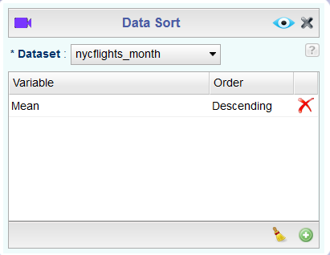

*Data Sort dialog box*

We obtain the following output:

[figure not shown]

*Data summary sorted in descending order by the Mean*

Note that there are actually 13 rows in this output: one for each month and one for All Observations. While this is not always useful, in this case we can also easily see which months were above or below the average departure delay for the entire dataset.

1. Suppose you really dislike departure delays and you want to schedule your travel in a month that minimizes your potential departure delay leaving NYC. One option is to choose the month with the lowest mean departure delay. Another option is to choose the month with the lowest median departure delay. What are the pros and cons of these two choices?

### On time departure rate for NYC airports

Suppose you will be flying out of NYC and want to know which of the three major NYC airports has the best on time departure rate of departing flights. Also suppose that for you, a flight that is delayed for less than 5 minutes is basically “on time.”” You consider any flight delayed for 5 minutes of more to be “delayed”.

In order to determine which airport has the best on time departure rate, you can

- first classify each flight as “on time” or “delayed”,
- then group flights by origin airport,
- then calculate on time departure rates for each origin airport,
- and finally sort the airports in descending order for on time departure percentage.

Let’s start with classifying each flight as “on time” or “delayed” by creating a new variable. In the **Data** toolbox, click **Functions** and select **Transform**. Then add a new variable called *dep_type* to the *nycflights* `Dataset` using the same sequence we learned in the previous lab. First, click the plus sign to add the variable, then give it an informative name (*dep_type*), then type some code in the middle box to indicate how to create *dep_type*. In this case, the code `ifelse(dep_delay < 5, "on time", "delayed")` indicates to classify the flight as `"on time"` if the flight is delayed by less than 5 minutes and `"delayed"` if not, i.e., if the flight is delayed by 5 or more minutes.

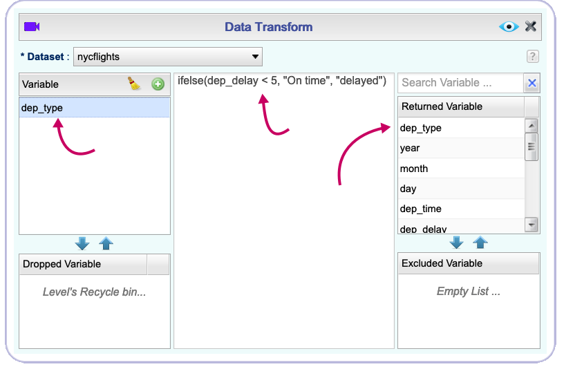

Click on the Preview button and **Save** the new dataset as *nycflights_ontime*.

With the new dataset saved, we can find the proportion of on-time flights out of each airport. In the **Analytics** toolbox, select **Tabulation $\rightarrow$ Categorical** and then select the dataset *nycflights_ontime*. Click the to add a table. We want to find the distribution of *dep_type* conditional on *origin*, so select those variables as `Factor 1` and `Factor 2`, respectively. Check the conditional box labeled as `Cond.` and check the `Proportions` box to tell Rguroo to calculate conditional proportions.

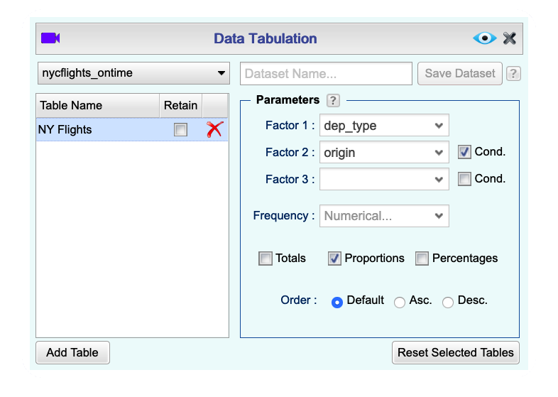

*Tabulating New York flights based on delay_type and origin*

1. If you were selecting an airport simply based on on time departure percentage, which NYC airport would you choose to fly out of?

You can also visualize the distribution of on on time departure rate across the three airports using a segmented bar plot.

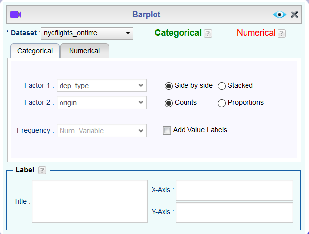

You may want to play around with changing from `Side by side` to `Stacked` and/or changing from `Counts` to `Proportions` to find the best visualization.

## More Practice

1. Using the **Transform** function, add a new variable to the dataset that contains the average speed, *avg_speed* traveled by the plane for each flight (in mph). **Hint:** Average speed can be calculated as distance divided by number of hours of travel, and note that *air_time* is given in minutes.
2. Make a scatterplot of *avg_speed* vs. *distance*. Describe the relationship between average speed and distance.
3. Replicate the following plot. **Hint:** The plot shows only flights from American Airlines (AA), Delta Airlines (DL), and United Airlines (UA), and the points are colored based on the `Factor` variable *carrier*. Rather than using **Subset**, you can click and use the **Factor Level Editor** attached to the plot to drop the unused levels and change the colors/symbols. Once you replicate the plot, determine (roughly) what the cutoff point is for departure delays where you can still expect to get to your destination on time.

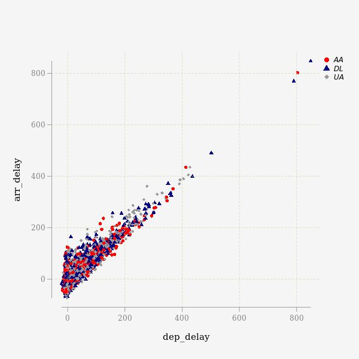

*Scatterplot of arrival delays as a function of departure delays*

This work is licensed under a [Creative Commons Attribution-ShareAlike 4.0 International License](http://creativecommons.org/licenses/by-sa/4.0/). Rguroo.com, the Rguroo.com logo, and all other trademarks, service marks, graphics and logos used in connection with Rguroo.com or the Website are trademarks or registered trademarks of Soflytics Corp. in the USA and other countries and are not included under the CC-BY-SA license.